# COVID

María Vázquez

# Regresión COVID

```r
library(readxl)
library(ggplot2)
library(dplyr)
library(magrittr)
library(ggplot2)
library(GGally)
```

Procesamos el dataset para poder trabajar con él.

```r
colnames(cs) <- c("Fecha", "Territorio", "Confirmados_PCR", "Hospitalizados", "UCI", "Curados", "Defunciones", "Total_confirmados")

juntos <-
  filter(cs, cs$Territorio == "Andalucía")

juntos <- mutate(juntos, Total = cumsum(Total_confirmados))



c <- juntos$Curados
h <- juntos$Hospitalizados
d <- juntos$Defunciones
uci <- juntos$UCI
conf <- juntos$Confirmados_PCR
totalconf <- juntos$Total_confirmados
salidac <- vector("numeric",length(c))
salidah <-vector("numeric",length(h))
salidad <- vector("numeric",length(d))
salidauci <- vector("numeric",length(uci))
salidaconf <- vector("numeric",length(conf))
salidatotalconf <- vector("numeric",length(totalconf))
for(i in seq_along(c)){

  salidac[length(c)+1-i] <- c[i]
  salidah[length(h)+1-i] <- h[i]
  salidad[length(d)+1-i] <- d[i]
  salidauci[length(uci)+1-i] <- uci[i]
  salidaconf[length(conf)+1-i] <- conf[i]
  salidatotalconf[length(totalconf)+1-i] <- totalconf[i]

}
juntos$Curados <- salidac
juntos$Hospitalizados <- salidah
juntos$Defunciones <- salidad
juntos$UCI <- salidauci
juntos$Confirmados_PCR <- salidaconf
juntos$Total_confirmados <- salidatotalconf

  fechas <- as.Date(juntos$Fecha ,"%d/%m/%Y")
juntos$Fecha <- sort(fechas)
```

Hacemos la gráfica de cómo han ido aumentando los casos en función del tiempo.

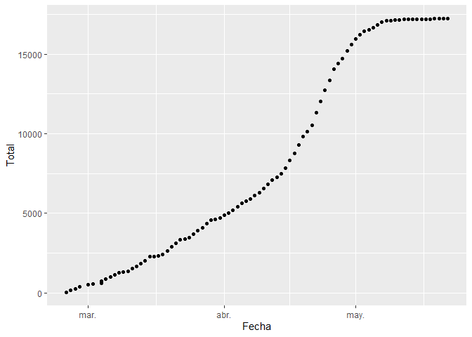

```r
attach(juntos)
grafica <- juntos %>% ggplot(aes(x= Fecha, y= Total))+geom_point()
grafica
```

En esta gráfica podemos ver como el número de casos hasta mayo aumentaba de forma exponencial. Sin embargo, a apartir de esta fecha se empieza a reducir el número de casos por día, llegando entonces a la famosa cima.

## Modelo del número de contagios respecto a la fecha

```r
modFC <- lm(formula = juntos$Total ~ juntos$Fecha, data = juntos)
modFC
```

```
##
## Call:
## lm(formula = juntos$Total ~ juntos$Fecha, data = juntos)
##
## Coefficients:
##  (Intercept)  juntos$Fecha
##   -4444803.2         242.5
```

```r
summary(modFC)
```

```
##
## Call:
## lm(formula = juntos$Total ~ juntos$Fecha, data = juntos)
##
## Residuals:
##     Min      1Q  Median      3Q     Max
## -2038.5 -1147.8  -133.7  1165.0  2423.5
##
## Coefficients:
##                Estimate Std. Error t value Pr(>|t|)
## (Intercept)  -4.445e+06  1.110e+05  -40.03   <2e-16 ***
## juntos$Fecha  2.425e+02  6.047e+00   40.11   <2e-16 ***
## ---
## Signif. codes:  0 '***' 0.001 '**' 0.01 '*' 0.05 '.' 0.1 ' ' 1
##
## Residual standard error: 1420 on 85 degrees of freedom
## Multiple R-squared:  0.9498, Adjusted R-squared:  0.9492
## F-statistic:  1609 on 1 and 85 DF,  p-value: < 2.2e-16
```

Empezamos comprobando si hay modelo, para ello miramos los valores de F-statistic y p-value. **F-statistic** está bastante alejado del 1 (1609), por lo que nos indica que hay modelo. **P-value**, está muy por debajo del 0.005, lo que nos confirma que hay modelo(Se cumple H1) Ahora que sabemos que hay modelo, vamos a estudiar cómo de bueno es nuestro modelo.

Miramos $R^2$, que tiene un valor de 0.9498, un valor bastante bueno, ya que el **94.98%** de los casos están recogidos con este modelo. También vemos que casi no hay diferencia entre $R^2$ ajustado y $R^2$, por lo que *no hay overfitting* en nuestro modelo y que los valores son relevantes(indicado por ***)

Sigamos estudiando el modelo, para ello vamos a ver las gráficas de los valores ajustados y residuos.

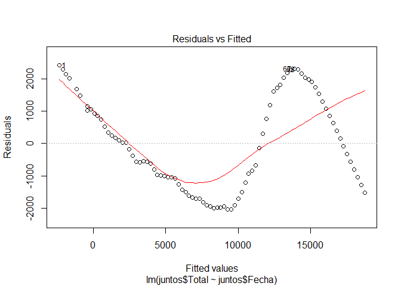

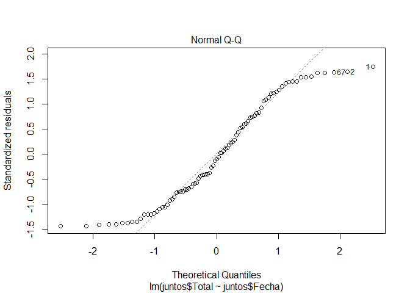

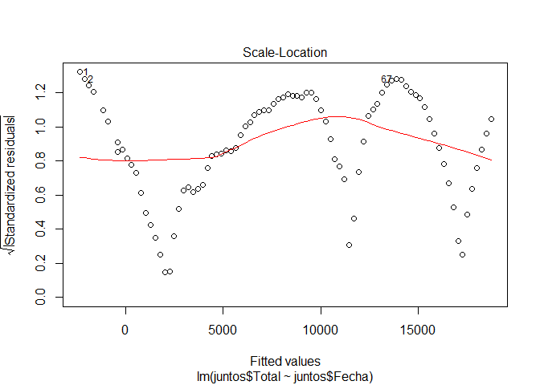

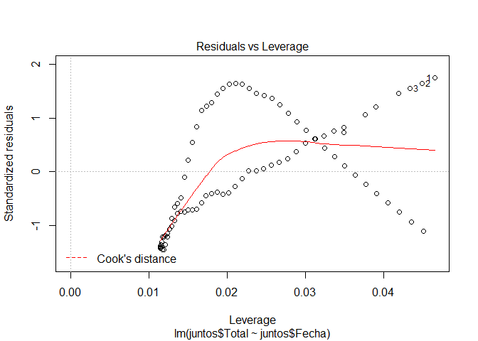

```r
plot(modFC)
```

## Modelo del número de personas que fueron hospitalizadas con respecto al número de contagiados.

```r
mHospitalizados <- lm(formula = Hospitalizados ~ Total_confirmados, data = juntos)
mHospitalizados
```

```
##
## Call:
## lm(formula = Hospitalizados ~ Total_confirmados, data = juntos)
##
## Coefficients:
##       (Intercept)  Total_confirmados
##          -31.5285             0.5212
```

```r
summary(mHospitalizados)
```

```
##
## Call:
## lm(formula = Hospitalizados ~ Total_confirmados, data = juntos)
##
## Residuals:
##     Min      1Q  Median      3Q     Max
## -98.696 -24.055   4.173  29.359  84.144
##
## Coefficients:
##                    Estimate Std. Error t value Pr(>|t|)
## (Intercept)       -31.52846    5.98438  -5.268 1.02e-06 ***
## Total_confirmados   0.52117    0.02246  23.200  < 2e-16 ***
## ---
## Signif. codes:  0 '***' 0.001 '**' 0.01 '*' 0.05 '.' 0.1 ' ' 1
##
## Residual standard error: 37.37 on 85 degrees of freedom
## Multiple R-squared:  0.8636, Adjusted R-squared:  0.862
## F-statistic: 538.3 on 1 and 85 DF,  p-value: < 2.2e-16
```

Empezamos comprobando si hay modelo, para ello miramos los valores de F-statistic y p-value. F-statistic está bastante alejado del 1 (538), por lo que nos indica que hay modelo. P-value, está muy por debajo del 0.005, lo que nos confirma que hay modelo(Se cumple H1) Ahora que sabemos que hay modelo, vamos a estudiar cómo de bueno es nuestro modelo.

Miramos $R^2$, que tiene un valor de 0.8636, un valor bastante bueno, ya que el 86.36% de los casos de hospitalización están recogidos en este modelo. También vemos que casi no hay diferencia entre $R^2$ ajustado y $R^2$, por lo que no hay overfitting en nuestro modelo y que los valores son relevantes(indicado por ***)

Sigamos estudiando el modelo, para ello vamos a ver las gráficas de los valores ajustados y residuos.

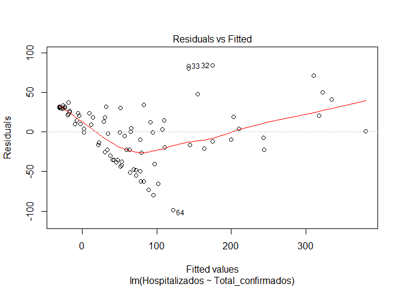

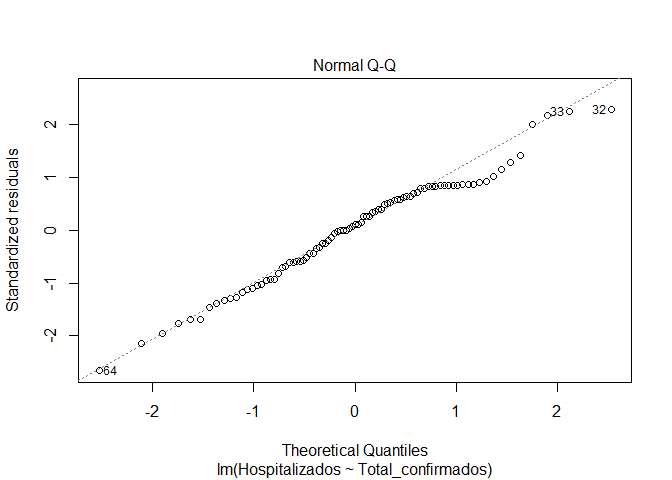

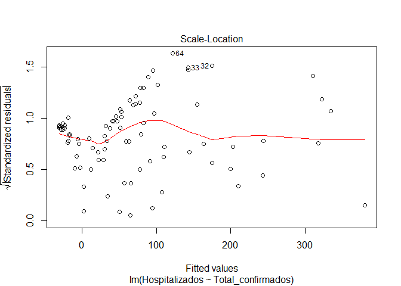

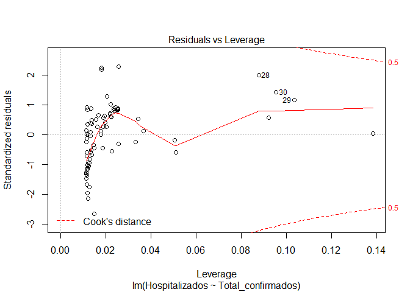

```r
plot(mHospitalizados)
```

En las gráficas podemos observar como hay dispersión de los valores, y como al principio se ajusta mejor que al final. También observamos que al principio del periodo el número de hospitalizados se acercaba bastante al número de casos. Pero a medida que se avanza en el tiempo el número de casos aumenta bastante, pero no tanto el número de hospitalizados. Esto puede ser debido a que se informó a la población de los primeros sintomas y las medidas que tenían que tomar, por lo que se podía detectar a una persona contagiada en las primeras fases y hacerle un control de forma que se podría reducir la gravedad.